# Post-COVID Demand Forecasting and Production Optimization in the Indian Automobile Sector: A Case Study of Indian Automobile Companies Using Machine Learning and Game Theory

## Understanding the Problem Statement

#### After COVID-19, India’s automobile market saw an unusual demand spike because people preferred personal vehicles over public transport. Indian utomakers had to scaleup production aggressively. But once the demand stabilized, unsold inventories piled up, forcing companies to sell cars at huge discounts (₹10k–50k per vehicle).

#### This highlights a forecasting and production mismatch problem—companies lacked accurate demand prediction and optimal production planning tools, leading to losses.

## Approach

#### Exploratory Data Analysis (EDA) – Visualize demand fluctuations, seasonal patterns, and post-COVID consumer behavior.

#### Machine Learning Forecasting – Use Linear Regression, Random Forest, and XGBoost to predict future demand.

#### Game Theory – Model competition between Mahindra and Honda to understand pricing and production strategies in a duopoly setting.

#### Model Evaluation – Assess models using RMSE, MAE, and R² to ensure reliability.

#### Strategic Insights – Recommend optimal production and sales strategies to minimize discounts and maximize profits.

## Objective

#### To accurately forecast demand in the post-COVID Indian automobile market.

#### To optimize production planning for automobile companies, reducing excess stock.

#### To apply ML + Game Theory for balancing demand, production, and competition.

#### To provide data-driven recommendations for sustainable profitability.

## Conclusion

#### This project demonstrates how machine learning forecasting + optimization + game theory can solve real-world challenges in the automobile industry. By forecasting demand more accurately, segmenting customer patterns, optimizing production, and analyzing competition, automobile companies can significantly reduce overproduction, cut unnecessary discounts, and sustain long-term profitability in a post-COVID market.

### Importing Libraries and Dependencies

```python
import pandas as pd
import numpy as np
import matplotlib.pyplot as plt
import seaborn as sns
```

### Loading the data

```python
mahindra_data = pd.read_csv(r"C:\Users\smcho\OneDrive\Desktop\Project 101\Real-Life-Project-Based-on-Automobile-Industry-\data\mahindra_dataset.csv")
honda_data = pd.read_csv(r"C:\Users\smcho\OneDrive\Desktop\Project 101\Real-Life-Project-Based-on-Automobile-Industry-\data\honda_dataset.csv")
hyundai_data = pd.read_csv(r"C:\Users\smcho\OneDrive\Desktop\Project 101\Real-Life-Project-Based-on-Automobile-Industry-\data\hyundai_dataset.csv")
kia_data = pd.read_csv(r"C:\Users\smcho\OneDrive\Desktop\Project 101\Real-Life-Project-Based-on-Automobile-Industry-\data\kia_dataset.csv")
maruti_n_data = pd.read_csv(r"C:\Users\smcho\OneDrive\Desktop\Project 101\Real-Life-Project-Based-on-Automobile-Industry-\data\maruti_n_dataset.csv")
skoda_data = pd.read_csv(r"C:\Users\smcho\OneDrive\Desktop\Project 101\Real-Life-Project-Based-on-Automobile-Industry-\data\skoda_dataset.csv")
tata_data = pd.read_csv(r"C:\Users\smcho\OneDrive\Desktop\Project 101\Real-Life-Project-Based-on-Automobile-Industry-\data\tata_dataset.csv")
vw_data = pd.read_csv(r"C:\Users\smcho\OneDrive\Desktop\Project 101\Real-Life-Project-Based-on-Automobile-Industry-\data\vw_dataset.csv")
```

### Understanding the data

```python
## For Mahindra
print(mahindra_data.head())
```

```
           VIN    SaleDate Region        State       Plant     Brand  \
0  MAH1410DS01  05-01-2019  North    Rajasthan      Chakan  Mahindra
1  MAH1410DS02  09-01-2019  South    Telangana      Chakan  Mahindra
2  MAH1410DS03  09-01-2019   East  West Bengal      Chakan  Mahindra
3  MAH1410DS04  13-01-2019   West      Gujarat  Zaheerabad  Mahindra
4  MAH1410DS05  16-01-2019   East        Bihar      Chakan  Mahindra

        Model FuelType  No_of_Cylinders  Mileage_mpg  ProductionUnits  \
0  XUV 400 EV       EV                0        196.9              171
1        BE 6       EV                0        169.6              117
2     XUV 3XO   Diesel                4         49.7               94
3        BE 6       EV                0        152.2               90
4        BE 6       EV                0        156.2               63

   SalesUnits  Price  Discount    Revenue      Profit  Year
0         171  16.22         0  248166000  74435071.0  2019
1         117  10.12     40000  109120000  34482189.0  2019
2          94   9.51     50000   81488000  27243278.0  2019
3          90  10.97     20000   84786000  21640351.0  2019
4          63  10.45         0   65835000  21726097.0  2019
```

```python
mahindra_data.info()
```

```
<class 'pandas.core.frame.DataFrame'>
RangeIndex: 1774 entries, 0 to 1773
Data columns (total 17 columns):
 #   Column           Non-Null Count  Dtype
---  ------           --------------  -----
 0   VIN              1774 non-null   object
 1   SaleDate         1774 non-null   object
 2   Region           1774 non-null   object
 3   State            1774 non-null   object
 4   Plant            1774 non-null   object
 5   Brand            1774 non-null   object
 6   Model            1774 non-null   object
 7   FuelType         1774 non-null   object
 8   No_of_Cylinders  1774 non-null   int64
 9   Mileage_mpg      1774 non-null   float64
 10  ProductionUnits  1774 non-null   int64
 11  SalesUnits       1774 non-null   int64
 12  Price            1774 non-null   float64
 13  Discount         1774 non-null   int64
 14  Revenue          1774 non-null   int64
 15  Profit           1774 non-null   float64
 16  Year             1774 non-null   int64
dtypes: float64(3), int64(6), object(8)
memory usage: 235.7+ KB
```

```python
print(mahindra_data.describe())
```

```
       No_of_Cylinders  Mileage_mpg  ProductionUnits   SalesUnits  \
count      1774.000000  1774.000000      1774.000000  1774.000000
mean          2.561443    79.650789       124.222097   150.924464
std           1.736896    63.763273        43.856509   137.030007
min           0.000000    25.100000        50.000000    25.000000
25%           0.000000    35.400000        86.000000    63.000000
50%           3.000000    42.000000       126.000000    94.000000
75%           4.000000   159.500000       163.000000   179.000000
max           4.000000   199.700000       200.000000   597.000000

             Price       Discount       Revenue        Profit         Year
count  1774.000000    1774.000000  1.774000e+03  1.774000e+03  1774.000000
mean     14.910761   34267.192785  1.306673e+08  3.943133e+07  2022.473506
std       4.269264   28381.787478  7.858885e+07  2.403015e+07     2.062784
min       9.010000       0.000000  1.938300e+07  6.228076e+06  2019.000000
25%      10.530000   10000.000000  7.087475e+07  2.109897e+07  2021.000000
50%      15.535000   30000.000000  1.105630e+08  3.383762e+07  2023.000000
75%      17.757500   50000.000000  1.747452e+08  5.265783e+07  2024.000000
max      24.990000  100000.000000  4.660400e+08  1.482440e+08  2025.000000
```

```python
print(mahindra_data.nunique())
```

```
VIN                1774
SaleDate           1048
Region                5
State                20
Plant                 5
Brand                 1
Model                 7
FuelType              3
No_of_Cylinders       3
Mileage_mpg         456
ProductionUnits     151
SalesUnits          301
Price               643
Discount              9
Revenue            1374
Profit             1387
Year                  7
dtype: int64
```

```python
## For Honda
print(honda_data.head())
```

```
           VIN    SaleDate Region        State          Plant  Brand  \
0  HND1410SD01  05-01-2019   West  Maharashtra       Tapukara  Honda
1  HND1410SD02  09-01-2019  South    Karnataka  Greater Noida  Honda
2  HND1410SD03  09-01-2019   West      Gujarat  Greater Noida  Honda
3  HND1410SD04  13-01-2019   East       Odisha       Tapukara  Honda
4  HND1410SD05  16-01-2019   West      Gujarat  Greater Noida  Honda

         Model FuelType  No_of_Cylinders  Mileage_mpg  ProductionUnits  \
0         City   Hybrid                4         56.8              186
1    City eHEV   Petrol                4         39.9              218
2    City eHEV   Petrol                4         45.9              192
3  Amaze 2 Gen   Diesel                4         53.3              196
4    City eHEV   Petrol                4         46.0              198

   SalesUnits  Price  Discount    Revenue      Profit  Year
0         174  13.25      2500  102960000  24446868.0  2019
1         206   9.16         0   86104000  20922382.0  2019
2         180   8.42     17500   65367000  16726345.0  2019
3         184  10.95      2500  105730000  22094621.0  2019
4         186  10.25     12500   90000000  26206517.0  2019
```

```python
honda_data.info()
```

```
<class 'pandas.core.frame.DataFrame'>
RangeIndex: 1774 entries, 0 to 1773
Data columns (total 17 columns):
 #   Column           Non-Null Count  Dtype
---  ------           --------------  -----
 0   VIN              1774 non-null   object
 1   SaleDate         1774 non-null   object
 2   Region           1774 non-null   object
 3   State            1774 non-null   object
 4   Plant            1774 non-null   object
 5   Brand            1774 non-null   object
 6   Model            1774 non-null   object
 7   FuelType         1774 non-null   object
 8   No_of_Cylinders  1774 non-null   int64
 9   Mileage_mpg      1774 non-null   float64
 10  ProductionUnits  1774 non-null   int64
 11  SalesUnits       1774 non-null   int64
 12  Price            1774 non-null   float64
 13  Discount         1774 non-null   int64
 14  Revenue          1774 non-null   int64
 15  Profit           1774 non-null   float64
 16  Year             1774 non-null   int64
dtypes: float64(3), int64(6), object(8)
memory usage: 235.7+ KB
```

```python
print(honda_data.describe())
```

```
       No_of_Cylinders  Mileage_mpg  ProductionUnits   SalesUnits  \
count           1774.0  1774.000000      1774.000000  1774.000000
mean               4.0    47.860992       329.313980   395.241826
std                0.0     6.386622       100.033587   351.068842
min                4.0    38.000000        94.000000    47.000000
25%                4.0    42.800000       244.000000   170.000000
50%                4.0    47.300000       336.000000   234.000000
75%                4.0    51.600000       420.000000   456.000000
max                4.0    64.900000       632.000000  1500.000000

             Price      Discount       Revenue        Profit         Year
count  1774.000000   1774.000000  1.774000e+03  1.774000e+03  1774.000000
mean     10.829673  14457.440812  1.277726e+08  3.198626e+07  2022.473506
std       2.337186  11064.889283  6.653016e+07  1.733553e+07     2.062784
min       7.050000      0.000000  2.977500e+07  6.574780e+06  2019.000000
25%       9.130000   5000.000000  7.942538e+07  1.925620e+07  2021.000000
50%      10.300000  12500.000000  1.114470e+08  2.813887e+07  2023.000000
75%      11.920000  20000.000000  1.655075e+08  4.138765e+07  2024.000000
max      16.980000  40000.000000  3.742160e+08  1.072863e+08  2025.000000
```

```python
print(honda_data.nunique())
```

```
VIN                1774
SaleDate           1048
Region                4
State                17
Plant                 2
Brand                 1
Model                 5
FuelType              3
No_of_Cylinders       1
Mileage_mpg         242
ProductionUnits     180
SalesUnits          365
Price               570
Discount             13
Revenue             994
Profit             1001
Year                  7
dtype: int64
```

```python
## For Hyundai
print(hyundai_data.head())
```

```
             VIN    SaleDate  Region       State    Plant    Brand    Model  \
0  HYU1410SD0007  23-04-2019    West         Goa  Chennai  Hyundai      i20
1  HYU1410SD0009  07-07-2019  Export       Dubai  Chennai  Hyundai    Creta
2  HYU1410SD0010  31-08-2019   South   Karnataka  Chennai  Hyundai  Alcazar
3  HYU1410SD0011  29-12-2019  Export  Bangladesh  Chennai  Hyundai    Creta
4  HYU1410SD0016  25-06-2019  Export   Sri Lanka  Chennai  Hyundai    Creta

  FuelType  No_of_Cylinders  Mileage_mpg  ProductionUnits  SalesUnits  Price  \
0   Diesel                4         40.3           162.20       704.8   9.21
1   Petrol                4         38.6            28.24       125.2  11.80
2   Diesel                4         27.4           178.56       746.4  21.60
3   Petrol                4         39.3           114.96       528.6  11.34
4   Diesel                4         34.5           123.84       162.2  14.56

   Discount    Revenue       Profit  Year
0     37341   50617659  12199687.52  2019
1     14025   84945975  17186098.13  2019
2     19352  203020648  38967371.50  2019
3     40794   90679206  20086221.16  2019
4     49977  209614023  46504599.62  2019
```

```python
hyundai_data.info()
```

```
<class 'pandas.core.frame.DataFrame'>
RangeIndex: 1775 entries, 0 to 1774
Data columns (total 17 columns):
 #   Column           Non-Null Count  Dtype
---  ------           --------------  -----
 0   VIN              1775 non-null   object
 1   SaleDate         1775 non-null   object
 2   Region           1775 non-null   object
 3   State            1775 non-null   object
 4   Plant            1775 non-null   object
 5   Brand            1775 non-null   object
 6   Model            1775 non-null   object
 7   FuelType         1775 non-null   object
 8   No_of_Cylinders  1775 non-null   int64
 9   Mileage_mpg      1775 non-null   float64
 10  ProductionUnits  1775 non-null   float64
 11  SalesUnits       1775 non-null   float64
 12  Price            1775 non-null   float64
 13  Discount         1775 non-null   int64
 14  Revenue          1775 non-null   int64
 15  Profit           1775 non-null   float64
 16  Year             1775 non-null   int64
dtypes: float64(5), int64(4), object(8)
memory usage: 235.9+ KB
```

```python
print(hyundai_data.describe())
```

```
       No_of_Cylinders  Mileage_mpg  ProductionUnits   SalesUnits  \
count       1775.00000  1775.000000      1775.000000  1775.000000
mean           3.76169    40.449352       137.241405   155.619944
std            0.42617     7.648183       158.023760   148.230965
min            3.00000    25.000000        20.000000    50.000000
25%            4.00000    35.200000        39.600000    80.000000
50%            4.00000    40.000000       110.000000   110.000000
75%            4.00000    47.100000       167.500000   150.000000
max            4.00000    54.900000       991.800000   945.800000

             Price      Discount       Revenue        Profit         Year
count  1775.000000   1775.000000  1.775000e+03  1.775000e+03  1775.000000
mean     11.465515  24786.777465  1.147903e+08  2.643512e+07  2022.001690
std       4.117418  14534.054418  5.837432e+07  1.403289e+07     1.994778
min       6.010000     18.000000  3.045669e+07  6.427425e+06  2019.000000
25%       8.055000  12270.500000  7.232236e+07  1.621727e+07  2020.000000
50%      10.150000  24945.000000  1.005625e+08  2.291723e+07  2022.000000
75%      14.105000  37098.000000  1.432167e+08  3.339467e+07  2024.000000
max      21.990000  49998.000000  3.714586e+08  1.027178e+08  2025.000000
```

```python
print(hyundai_data.nunique())
```

```
VIN                1775
SaleDate           1293
Region                5
State                24
Plant                 1
Brand                 1
Model                 7
FuelType              2
No_of_Cylinders       2
Mileage_mpg         289
ProductionUnits     589
SalesUnits          342
Price               950
Discount           1748
Revenue            1775
Profit             1775
Year                  7
dtype: int64
```

```python
## For Kia
print(kia_data.head())
```

```
           VIN    SaleDate Region       State    Plant Brand Model FuelType  \
0  KIA1410DS07  10-09-2019   East      Odisha     Pune   Kia   EV6       EV
1  KIA1410DS30  28-02-2019  South  Tamil Nadu  Chennai   Kia   EV9       EV
2  KIA1410DS35  10-08-2019  South  Tamil Nadu     Pune   Kia   EV9       EV
3  KIA1410DS46  05-07-2019   East      Odisha  Chennai   Kia   EV6       EV
4  KIA1410DS47  04-07-2019  South   Telangana  Chennai   Kia   EV5       EV

   No_of_Cylinders  Mileage_mpg  ProductionUnits  SalesUnits       Price  \
0                0        151.1            183.0       447.0  2143721.24
1                0        188.9            150.0       180.0  2285521.94
2                0        176.3            103.0       231.0  2724772.87
3                0        167.6            216.0       582.0  2103336.65
4                0        162.7            233.0       372.0  1851198.56

   Discount      Revenue        Profit  Year
0     46593  312472107.8  1.043217e+08  2019
1     31448  135244436.4  4.921208e+07  2019
2     19813  208281910.0  7.997210e+07  2019
3     43028  399699878.1  1.371691e+08  2019
4     19956  227074077.4  6.532281e+07  2019
```

```python
kia_data.info()
```

```
<class 'pandas.core.frame.DataFrame'>
RangeIndex: 1775 entries, 0 to 1774
Data columns (total 17 columns):
 #   Column           Non-Null Count  Dtype
---  ------           --------------  -----
 0   VIN              1775 non-null   object
 1   SaleDate         1775 non-null   object
 2   Region           1775 non-null   object
 3   State            1775 non-null   object
 4   Plant            1775 non-null   object
 5   Brand            1775 non-null   object
 6   Model            1775 non-null   object
 7   FuelType         1775 non-null   object
 8   No_of_Cylinders  1775 non-null   int64
 9   Mileage_mpg      1775 non-null   float64
 10  ProductionUnits  1775 non-null   float64
 11  SalesUnits       1775 non-null   float64
 12  Price            1775 non-null   float64
 13  Discount         1775 non-null   int64
 14  Revenue          1775 non-null   float64
 15  Profit           1775 non-null   float64
 16  Year             1775 non-null   int64
dtypes: float64(6), int64(3), object(8)
memory usage: 235.9+ KB
```

```python
print(kia_data.describe())
```

```
       No_of_Cylinders  Mileage_mpg  ProductionUnits   SalesUnits  \
count      1775.000000  1775.000000      1775.000000  1775.000000
mean          1.863099   109.699662       246.431211   285.887662
std           1.892806    69.183249       105.546202   141.680396
min           0.000000    28.000000       100.000000    67.500000
25%           0.000000    41.800000       165.000000   174.000000
50%           0.000000   150.300000       222.200000   261.000000
75%           4.000000   174.200000       309.000000   375.000000
max           4.000000   209.800000       500.000000   723.000000

              Price      Discount       Revenue        Profit         Year
count  1.775000e+03   1775.000000  1.775000e+03  1.775000e+03  1775.000000
mean   1.938884e+06  27704.971831  2.156799e+08  6.467990e+07  2022.032676
std    7.204414e+05  13097.854297  1.201808e+08  3.868517e+07     2.024665
min    9.001817e+05   5004.000000  4.593224e+07  9.847568e+06  2019.000000
25%    1.398275e+06  16543.000000  1.289149e+08  3.692333e+07  2020.000000
50%    1.847090e+06  27300.000000  1.841985e+08  5.500064e+07  2022.000000
75%    2.306088e+06  39463.000000  2.716934e+08  8.217437e+07  2024.000000
max    3.999412e+06  49983.000000  8.419087e+08  2.509840e+08  2025.000000
```

```python
print(kia_data.nunique())
```

```
VIN                1775
SaleDate           1279
Region                4
State                16
Plant                 4
Brand                 1
Model                 8
FuelType              3
No_of_Cylinders       3
Mileage_mpg         655
ProductionUnits     410
SalesUnits          327
Price              1775
Discount           1747
Revenue            1775
Profit             1775
Year                  7
dtype: int64
```

```python
## For Maruti Nexa
print(maruti_n_data.head())
```

```
           VIN    SaleDate Region          State    Plant        Brand  \
0  MAR2110SD01  05-01-2019  North          Delhi  Gurgaon  Maruti Nexa
1  MAR2110SD02  09-01-2019  South     Tamil Nadu  Manesar  Maruti Nexa
2  MAR2110SD03  09-01-2019   West    Maharashtra  Gurgaon  Maruti Nexa
3  MAR2110SD04  13-01-2019   East    West Bengal  Manesar  Maruti Nexa
4  MAR2110SD05  13-01-2019  North  Uttar Pradesh  Gurgaon  Maruti Nexa

     Model FuelType  No_of_Cylinders  Mileage_mpg  ProductionUnits  \
0   Baleno   Petrol                4        23.87            586.2
1     Ciaz   Petrol                4        20.65            364.4
2    Ignis   Petrol                4        20.89            290.2
3  S-Cross   Diesel                4        24.00            657.0
4      XL6   Petrol                4        19.01            440.6

   SalesUnits  Price  Discount   Revenue   Profit  Year
0       594.4    7.0      1500  10150000  2000000  2019
1       726.4   10.0      2000  11800000  2500000  2019
2       434.8    6.0      1200   9900000  1800000  2019
3       786.0   10.0      3000   8800000  1500000  2019
4       482.6   11.0      2500  13750000  3000000  2019
```

```python
maruti_n_data.info()
```

```
<class 'pandas.core.frame.DataFrame'>
RangeIndex: 1535 entries, 0 to 1534
Data columns (total 17 columns):
 #   Column           Non-Null Count  Dtype
---  ------           --------------  -----
 0   VIN              1535 non-null   object
 1   SaleDate         1535 non-null   object
 2   Region           1535 non-null   object
 3   State            1535 non-null   object
 4   Plant            1535 non-null   object
 5   Brand            1535 non-null   object
 6   Model            1535 non-null   object
 7   FuelType         1535 non-null   object
 8   No_of_Cylinders  1535 non-null   int64
 9   Mileage_mpg      1535 non-null   float64
 10  ProductionUnits  1535 non-null   float64
 11  SalesUnits       1535 non-null   float64
 12  Price            1535 non-null   float64
 13  Discount         1535 non-null   int64
 14  Revenue          1535 non-null   int64
 15  Profit           1535 non-null   int64
 16  Year             1535 non-null   int64
dtypes: float64(4), int64(5), object(8)
memory usage: 204.0+ KB
```

```python
print(maruti_n_data.describe())
```

```
       No_of_Cylinders  Mileage_mpg  ProductionUnits   SalesUnits  \
count      1535.000000  1535.000000      1535.000000  1535.000000
mean          3.829316    22.358300       287.134897   447.878176
std           0.376355     1.818301       222.358175   278.386590
min           3.000000    19.010000        42.666667    65.000000
25%           4.000000    20.890000       115.900000   191.700000
50%           4.000000    22.000000       184.000000   411.200000
75%           4.000000    24.000000       423.700000   676.200000
max           4.000000    25.000000       963.800000  1000.000000

             Price      Discount       Revenue        Profit         Year
count  1535.000000   1535.000000  1.535000e+03  1.535000e+03  1535.000000
mean     10.562736  14730.879479  3.524386e+07  6.475381e+06  2021.585668
std       3.144840  15362.069059  4.293794e+07  7.949057e+06     1.932783
min       5.500000   1200.000000  6.705000e+05  1.670000e+03  2019.000000
25%       8.200000   2000.000000  3.074600e+06  6.612300e+05  2020.000000
50%      10.000000   7900.000000  7.255800e+06  1.497780e+06  2021.000000
75%      12.300000  25500.000000  6.187500e+07  1.100000e+07  2023.000000
max      20.300000  61500.000000  1.765500e+08  3.260000e+07  2025.000000
```

```python
print(maruti_n_data.nunique())
```

```
VIN                1535
SaleDate           1005
Region                4
State                22
Plant                 3
Brand                 2
Model                10
FuelType              2
No_of_Cylinders       2
Mileage_mpg           8
ProductionUnits    1037
SalesUnits         1019
Price               149
Discount            188
Revenue            1166
Profit              808
Year                  7
dtype: int64
```

```python
## For Tata
print(tata_data.head())
```

```
            VIN    SaleDate Region        State       Plant Brand     Model  \
0  TAT1410SD717  13-12-2021  North    Jharkhand        Pune  Tata    Safari
1  TAT1410SD718  14-12-2021   West  Maharashtra  Ranjangaon  Tata     Nexon
2  TAT1410SD719  16-12-2021  South       Kerala        Pune  Tata     Tigor
3  TAT1410SD720  18-12-2021   East       Odisha        Pune  Tata  Tiago EV
4  TAT1410SD721  19-12-2021  North        Delhi        Pune  Tata  Nexon EV

  FuelType  No_of_Cylinders  Mileage_mpg  ProductionUnits  SalesUnits  Price  \
0   Diesel              4.0         36.7            134.6       446.4   9.21
1   Petrol              4.0         46.7            194.2      1266.4  11.80
2   Petrol              3.0         39.9            280.2      1994.0  21.60
3       EV              0.0        152.2            107.8       364.8  21.60
4       EV              0.0        196.9            320.2       929.2  14.56

   Discount       Revenue       Profit    Year
0   46593.0  1.242422e+09  406528703.0  2025.0
1   31448.0  1.122500e+09  321356023.0  2025.0
2   19813.0  6.213960e+08  155104712.0  2025.0
3   43028.0  7.058950e+08  147372175.0  2025.0
4   19956.0  1.799714e+09  530184640.0  2025.0
```

```python
tata_data.info()
```

```
<class 'pandas.core.frame.DataFrame'>
RangeIndex: 759 entries, 0 to 758
Data columns (total 17 columns):
 #   Column           Non-Null Count  Dtype
---  ------           --------------  -----
 0   VIN              758 non-null    object
 1   SaleDate         758 non-null    object
 2   Region           758 non-null    object
 3   State            758 non-null    object
 4   Plant            758 non-null    object
 5   Brand            758 non-null    object
 6   Model            758 non-null    object
 7   FuelType         758 non-null    object
 8   No_of_Cylinders  758 non-null    float64
 9   Mileage_mpg      758 non-null    float64
 10  ProductionUnits  758 non-null    float64
 11  SalesUnits       758 non-null    float64
 12  Price            758 non-null    float64
 13  Discount         758 non-null    float64
 14  Revenue          758 non-null    float64
 15  Profit           758 non-null    float64
 16  Year             758 non-null    float64
dtypes: float64(9), object(8)
memory usage: 100.9+ KB
```

```python
print(tata_data.describe())
```

```
       No_of_Cylinders  Mileage_mpg  ProductionUnits   SalesUnits       Price  \
count       758.000000   758.000000       758.000000   758.000000  758.000000
mean          2.502639    85.051055       176.283509   298.874494   11.434749
std           1.688994    58.690734       131.924477   314.550097    4.170078
min           0.000000    36.700000        32.500000    42.666667    6.030000
25%           0.000000    46.700000        75.000000    97.333333    8.012500
50%           3.000000    50.950000       128.125000   166.333333   10.075000
75%           4.000000   152.200000       250.500000   430.200000   13.960000
max           4.000000   196.900000       903.400000  1994.000000   21.990000

           Discount       Revenue        Profit         Year
count    758.000000  7.580000e+02  7.580000e+02   758.000000
mean   28031.029024  5.567255e+08  1.602792e+08  2021.311346
std    12788.703026  3.393033e+08  1.052379e+08     1.778531
min     5080.000000  8.541800e+07  2.021000e+03  2019.000000
25%    17767.000000  3.065475e+08  8.315661e+07  2020.000000
50%    27674.500000  4.935305e+08  1.342409e+08  2021.000000
75%    38857.750000  7.011230e+08  2.094915e+08  2022.000000
max    49948.000000  1.862852e+09  5.487897e+08  2025.000000
```

```python
print(tata_data.nunique())
```

```
VIN                758
SaleDate           756
Region               4
State               16
Plant                2
Brand                1
Model               10
FuelType             3
No_of_Cylinders      3
Mileage_mpg         10
ProductionUnits    371
SalesUnits         459
Price              561
Discount           753
Revenue            757
Profit             758
Year                 7
dtype: int64
```

```python
## For Skoda
print(skoda_data.head())
```

```
         VIN    SaleDate Region          State    Plant  Brand         Model  \
0  VIN100005  06-11-2019   West        Gujarat  Chennai  Skoda  Skoda Kushaq
1  VIN100006  15-01-2019   West      Karnataka  Chennai  Skoda  Skoda Kyliaq
2  VIN100010  27-11-2019   East    Maharashtra  Lucknow  Skoda  Skoda Kyliaq
3  VIN100016  06-04-2019  North  Uttar Pradesh  Gurgaon  Skoda  Skoda Slavia
4  VIN100017  10-09-2019   East      Karnataka  Chennai  Skoda  Skoda Kyliaq

  FuelType  No_of_Cylinders  Mileage_mpg  ProductionUnits  SalesUnits  \
0   Hybrid                6        14.91            155.8       239.0
1   Petrol                6        17.42            492.3       420.2
2   Petrol                6        21.24            364.0       599.2
3   Diesel                3        21.97            215.5       363.8
4   Hybrid                3        22.47            498.5       280.2

     Price  Discount      Revenue        Profit  Year
0  3000000   3182.32   3489928190  4.674876e+08  2019
1  2900000   2398.84   5966900929  1.021515e+09  2019
2  3600000   2983.68  10562122368  2.262627e+09  2019
3  2800000   2344.72   4986573858  6.230999e+08  2019
4  2400000   3192.00   1171701000  1.678486e+08  2019
```

```python
skoda_data.info()
```

```
<class 'pandas.core.frame.DataFrame'>
RangeIndex: 1775 entries, 0 to 1774
Data columns (total 17 columns):
 #   Column           Non-Null Count  Dtype
---  ------           --------------  -----
 0   VIN              1775 non-null   object
 1   SaleDate         1775 non-null   object
 2   Region           1775 non-null   object
 3   State            1775 non-null   object
 4   Plant            1775 non-null   object
 5   Brand            1775 non-null   object
 6   Model            1775 non-null   object
 7   FuelType         1775 non-null   object
 8   No_of_Cylinders  1775 non-null   int64
 9   Mileage_mpg      1775 non-null   float64
 10  ProductionUnits  1775 non-null   float64
 11  SalesUnits       1775 non-null   float64
 12  Price            1775 non-null   int64
 13  Discount         1775 non-null   float64
 14  Revenue          1775 non-null   int64
 15  Profit           1775 non-null   float64
 16  Year             1775 non-null   int64
dtypes: float64(5), int64(4), object(8)
memory usage: 235.9+ KB
```

```python
print(skoda_data.describe())
```

```
       No_of_Cylinders  Mileage_mpg  ProductionUnits   SalesUnits  \
count      1775.000000  1775.000000      1775.000000  1775.000000
mean          4.350986    18.462372       277.788282   321.129577
std           1.255054     3.728599       133.578009   209.019756
min           3.000000    12.000000        50.000000    80.000000
25%           3.000000    15.270000       159.700000   148.200000
50%           4.000000    18.390000       280.600000   256.000000
75%           6.000000    21.590000       397.050000   453.700000
max           6.000000    25.000000       499.900000   963.800000

              Price     Discount       Revenue        Profit         Year
count  1.775000e+03  1775.000000  1.775000e+03  1.775000e+03  1775.000000
mean   2.497634e+06  2393.758107  3.878774e+09  6.795991e+08  2022.077183
std    8.968786e+05   929.818265  3.042946e+09  5.677917e+08     2.028326
min    1.000000e+06   800.880000  3.771994e+08  4.365831e+07  2019.000000
25%    1.700000e+06  1600.920000  1.690247e+09  2.774543e+08  2020.000000
50%    2.500000e+06  2395.080000  2.980354e+09  4.992765e+08  2022.000000
75%    3.300000e+06  3226.200000  5.094333e+09  8.855300e+08  2024.000000
max    4.000000e+06  3999.440000  1.722491e+10  4.255561e+09  2025.000000
```

```python
print(skoda_data.nunique())
```

```
VIN                1775
SaleDate           1237
Region                5
State                 6
Plant                 6
Brand                 1
Model                 4
FuelType              4
No_of_Cylinders       3
Mileage_mpg         981
ProductionUnits    1415
SalesUnits         1262
Price                31
Discount           1762
Revenue            1775
Profit             1775
Year                  7
dtype: int64
```

```python
## For Volkwagen
print(vw_data.head())
```

```
           VIN    SaleDate Region        State   Plant       Brand   Model  \
0  VWG1410SD01  05-01-2019   West  Maharashtra    Pune  Volkswagen    Polo
1  VWG1410SD02  09-01-2019  South    Karnataka    Pune  Volkswagen  Tiguan
2  VWG1410SD03  09-01-2019   West      Gujarat    Pune  Volkswagen   Vento
3  VWG1410SD04  13-01-2019   East       Odisha  Chakan  Volkswagen    Polo
4  VWG1410SD05  17-01-2019  North        Delhi    Pune  Volkswagen  Taigun

  FuelType  No_of_Cylinders  Mileage_mpg  ProductionUnits  SalesUnits  Price  \
0   Petrol              4.0         18.7            190.0       239.0    9.5
1   Diesel              4.0         15.6            210.0       420.2   10.2
2   Petrol              4.0         17.2            180.0       599.2    8.8
3   Petrol              4.0         18.7            195.0       363.8    9.5
4   Petrol              3.0         18.1            200.0       280.2   11.5

   Discount      Revenue      Profit    Year
0   3182.32  105000000.0  25000000.0  2019.0
1   2398.84  125000000.0  30000000.0  2019.0
2   2983.68   95000000.0  22000000.0  2019.0
3   2344.72  110000000.0  26000000.0  2019.0
4   3192.00  135000000.0  35000000.0  2019.0
```

```python
vw_data.info()
```

```
<class 'pandas.core.frame.DataFrame'>
RangeIndex: 775 entries, 0 to 774
Data columns (total 17 columns):
 #   Column           Non-Null Count  Dtype
---  ------           --------------  -----
 0   VIN              774 non-null    object
 1   SaleDate         774 non-null    object
 2   Region           774 non-null    object
 3   State            774 non-null    object
 4   Plant            774 non-null    object
 5   Brand            774 non-null    object
 6   Model            774 non-null    object
 7   FuelType         774 non-null    object
 8   No_of_Cylinders  774 non-null    float64
 9   Mileage_mpg      774 non-null    float64
 10  ProductionUnits  774 non-null    float64
 11  SalesUnits       774 non-null    float64
 12  Price            774 non-null    float64
 13  Discount         774 non-null    float64
 14  Revenue          774 non-null    float64
 15  Profit           774 non-null    float64
 16  Year             774 non-null    float64
dtypes: float64(9), object(8)
memory usage: 103.1+ KB
```

```python
print(vw_data.describe())
```

```
       No_of_Cylinders  Mileage_mpg  ProductionUnits  SalesUnits       Price  \
count       774.000000   774.000000       774.000000  774.000000  774.000000
mean          3.801034    17.797804       204.481912  319.667959   10.392119
std           0.399481     1.315991        56.019953  209.574425    1.197314
min           3.000000    15.600000        90.000000   80.000000    8.800000
25%           4.000000    17.200000       185.000000  146.500000    9.500000
50%           4.000000    18.100000       210.000000  258.400000   10.200000
75%           4.000000    18.700000       243.000000  451.700000   11.500000
max           4.000000    19.400000       288.500000  963.800000   12.000000

          Discount       Revenue        Profit         Year
count   774.000000  7.740000e+02  7.740000e+02   774.000000
mean   2417.429767  1.221783e+08  3.025969e+07  2021.534884
std     934.822559  1.958731e+07  6.159250e+06     2.095569
min     814.360000  9.500000e+07  2.200000e+07  2019.000000
25%    1612.270000  1.020000e+08  2.400000e+07  2020.000000
50%    2433.960000  1.250000e+08  3.000000e+07  2021.000000
75%    3243.270000  1.400000e+08  3.600000e+07  2023.000000
max    3999.440000  1.500000e+08  3.900000e+07  2025.000000
```

```python
print(vw_data.nunique())
```

```
VIN                774
SaleDate           639
Region               4
State               19
Plant                2
Brand                1
Model                5
FuelType             2
No_of_Cylinders      2
Mileage_mpg          5
ProductionUnits     29
SalesUnits         657
Price                5
Discount           773
Revenue             11
Profit              11
Year                 7
dtype: int64
```

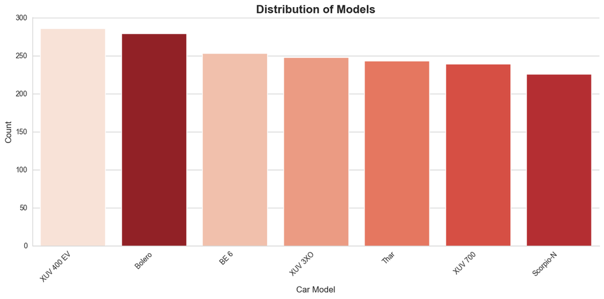

```python
import seaborn as sns
import matplotlib.pyplot as plt

plt.figure(figsize=(12,6))  # Bigger figure
sns.set_style("whitegrid")  # Clean background

sns.countplot(
    x="Model",
    data=mahindra_data,
    hue="Model",  # <-- Explicit hue
    palette="Reds",
    order=mahindra_data["Model"].value_counts().index,
    legend=False  # <-- Hide redundant legend
)

plt.xticks(rotation=45, ha="right", fontsize=10)
plt.title("Distribution of Models", fontsize=16, fontweight="bold")
plt.xlabel("Car Model", fontsize=12)
plt.ylabel("Count", fontsize=12)

sns.despine()
plt.tight_layout()
plt.show()
```

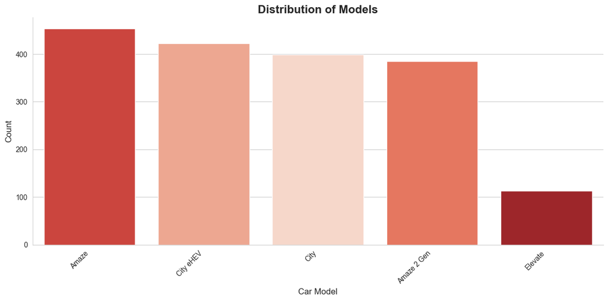

```python
import seaborn as sns
import matplotlib.pyplot as plt

plt.figure(figsize=(12,6))  # Bigger figure
sns.set_style("whitegrid")  # Clean background

sns.countplot(
    x="Model",
    data=honda_data,
    hue="Model",  # <-- Explicit hue
    palette="Reds",
    order=honda_data["Model"].value_counts().index,
    legend=False  # <-- Hvide redundant legend
)

plt.xticks(rotation=45, ha="right", fontsize=10)
plt.title("Distribution of Models", fontsize=16, fontweight="bold")
plt.xlabel("Car Model", fontsize=12)
plt.ylabel("Count", fontsize=12)

sns.despine()
plt.tight_layout()
plt.show()
```

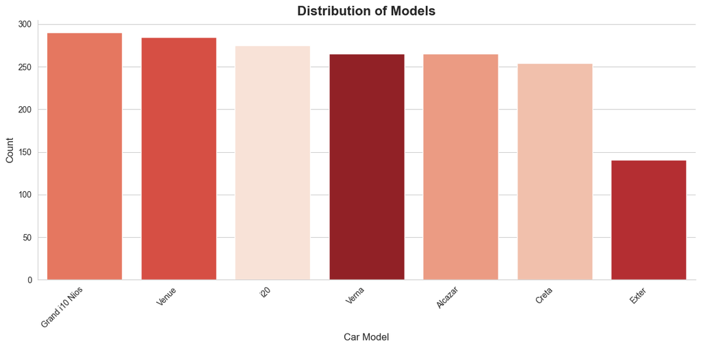

```python
import seaborn as sns
import matplotlib.pyplot as plt

plt.figure(figsize=(12,6))  # Bigger figure
sns.set_style("whitegrid")  # Clean background

sns.countplot(
    x="Model",
    data=hyundai_data,
    hue="Model",  # <-- Explicit hue
    palette="Reds",
    order=hyundai_data["Model"].value_counts().index,
    legend=False  # <-- Hvide redundant legend
)

plt.xticks(rotation=45, ha="right", fontsize=10)
plt.title("Distribution of Models", fontsize=16, fontweight="bold")
plt.xlabel("Car Model", fontsize=12)
plt.ylabel("Count", fontsize=12)

sns.despine()
plt.tight_layout()
plt.show()
```

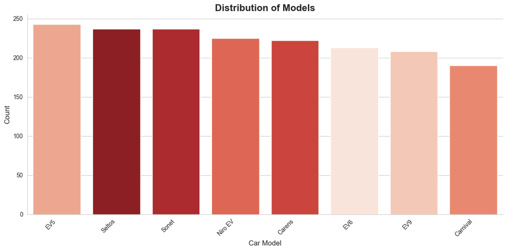

```python
import seaborn as sns
import matplotlib.pyplot as plt

plt.figure(figsize=(12,6))  # Bigger figure
sns.set_style("whitegrid")  # Clean background

sns.countplot(
    x="Model",
    data=kia_data,
    hue="Model",  # <-- Explicit hue
    palette="Reds",
    order=kia_data["Model"].value_counts().index,
    legend=False  # <-- Hvide redundant legend
)

plt.xticks(rotation=45, ha="right", fontsize=10)
plt.title("Distribution of Models", fontsize=16, fontweight="bold")
plt.xlabel("Car Model", fontsize=12)
plt.ylabel("Count", fontsize=12)

sns.despine()
plt.tight_layout()
plt.show()
```

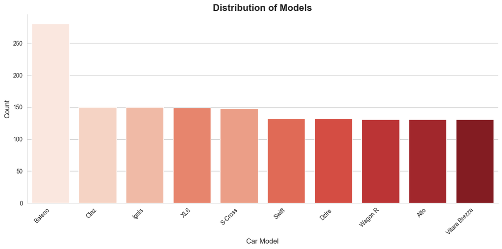

```python
import seaborn as sns
import matplotlib.pyplot as plt

plt.figure(figsize=(12,6))  # Bigger figure
sns.set_style("whitegrid")  # Clean background

sns.countplot(
    x="Model",
    data=maruti_n_data,
    hue="Model",  # <-- Explicit hue
    palette="Reds",
    order=maruti_n_data["Model"].value_counts().index,
    legend=False  # <-- Hvide redundant legend
)

plt.xticks(rotation=45, ha="right", fontsize=10)
plt.title("Distribution of Models", fontsize=16, fontweight="bold")
plt.xlabel("Car Model", fontsize=12)
plt.ylabel("Count", fontsize=12)

sns.despine()
plt.tight_layout()
plt.show()
```

```python
import seaborn as sns
import matplotlib.pyplot as plt

plt.figure(figsize=(12,6))  # Bigger figure
sns.set_style("whitegrid")  # Clean background

sns.countplot(
    x="Model",
    data=maruti_a_data,
    hue="Model",  # <-- Explicit hue
    palette="Reds",
    order=maruti_a_data["Model"].value_counts().index,
    legend=False  # <-- Hvide redundant legend
)

plt.xticks(rotation=45, ha="right", fontsize=10)
plt.title("Distribution of Models", fontsize=16, fontweight="bold")
plt.xlabel("Car Model", fontsize=12)
plt.ylabel("Count", fontsize=12)

sns.despine()
plt.tight_layout()
plt.show()
```

[output not shown]

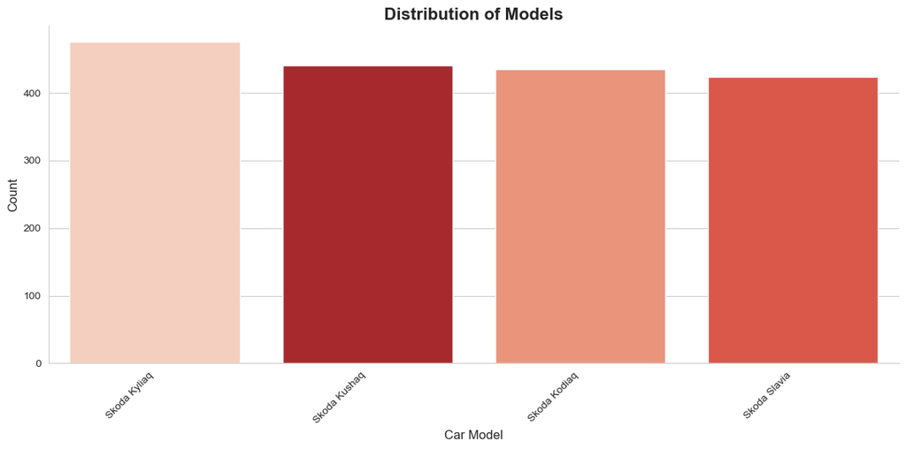

```python
import seaborn as sns
import matplotlib.pyplot as plt

plt.figure(figsize=(12,6))  # Bigger figure
sns.set_style("whitegrid")  # Clean background

sns.countplot(
    x="Model",
    data=skoda_data,
    hue="Model",  # <-- Explicit hue
    palette="Reds",
    order=skoda_data["Model"].value_counts().index,
    legend=False  # <-- Hvide redundant legend
)

plt.xticks(rotation=45, ha="right", fontsize=10)
plt.title("Distribution of Models", fontsize=16, fontweight="bold")
plt.xlabel("Car Model", fontsize=12)
plt.ylabel("Count", fontsize=12)

sns.despine()
plt.tight_layout()
plt.show()
```

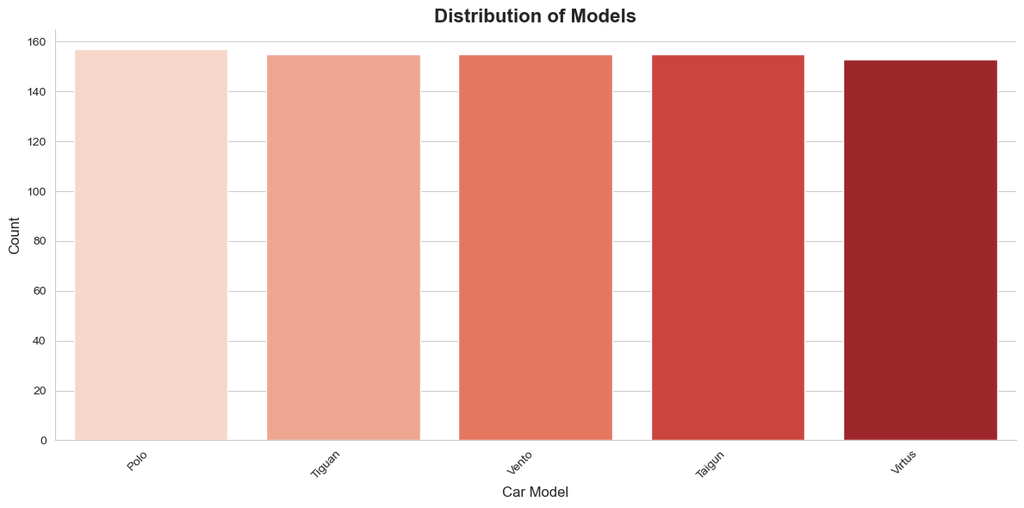

```python
import seaborn as sns
import matplotlib.pyplot as plt

plt.figure(figsize=(12,6))  # Bigger figure
sns.set_style("whitegrid")  # Clean background

sns.countplot(
    x="Model",
    data=vw_data,
    hue="Model",  # <-- Explicit hue
    palette="Reds",
    order=vw_data["Model"].value_counts().index,
    legend=False  # <-- Hvide redundant legend
)

plt.xticks(rotation=45, ha="right", fontsize=10)
plt.title("Distribution of Models", fontsize=16, fontweight="bold")
plt.xlabel("Car Model", fontsize=12)
plt.ylabel("Count", fontsize=12)

sns.despine()
plt.tight_layout()
plt.show()
```

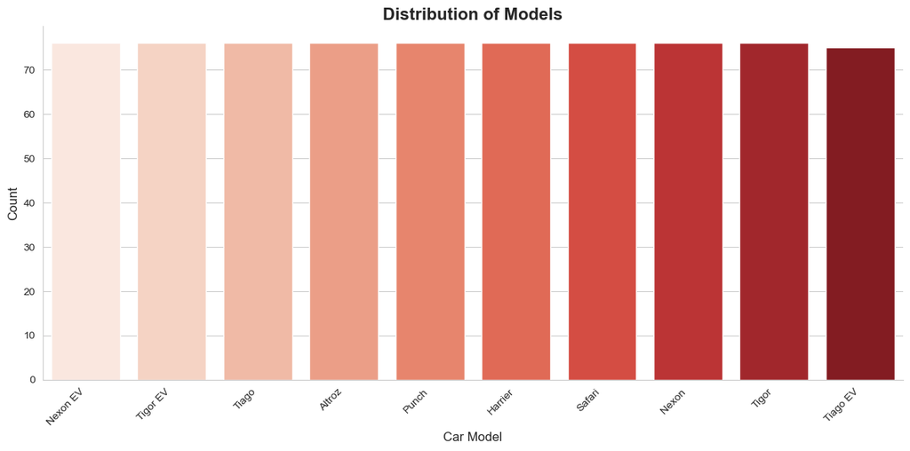

```python
import seaborn as sns
import matplotlib.pyplot as plt

plt.figure(figsize=(12,6))  # Bigger figure
sns.set_style("whitegrid")  # Clean background

sns.countplot(
    x="Model",
    data=tata_data,
    hue="Model",  # <-- Explicit hue
    palette="Reds",
    order=tata_data["Model"].value_counts().index,
    legend=False  # <-- Hvide redundant legend
)

plt.xticks(rotation=45, ha="right", fontsize=10)
plt.title("Distribution of Models", fontsize=16, fontweight="bold")
plt.xlabel("Car Model", fontsize=12)
plt.ylabel("Count", fontsize=12)

sns.despine()
plt.tight_layout()
plt.show()
```

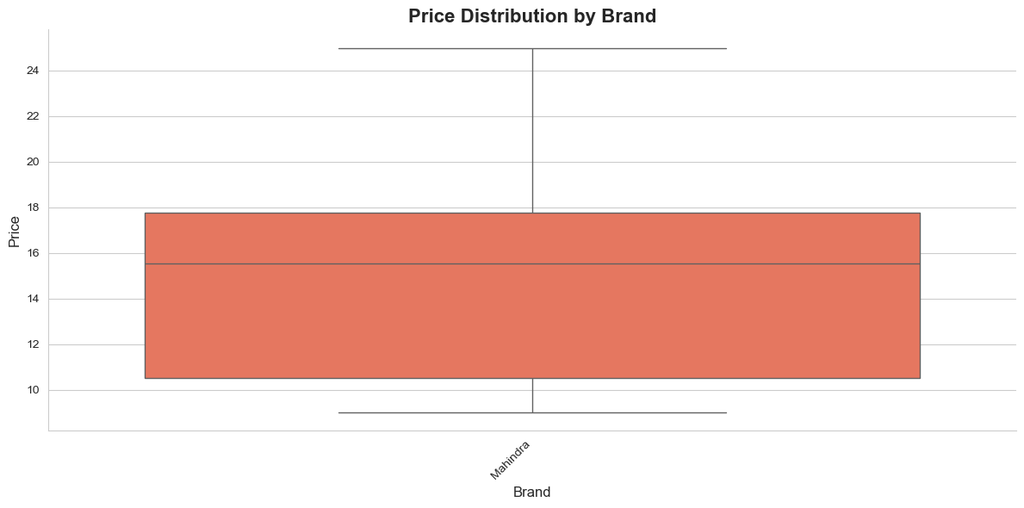

```python
import seaborn as sns
import matplotlib.pyplot as plt

plt.figure(figsize=(12,6))
sns.set_style("whitegrid")  # Clean background

sns.boxplot(
    x="Brand",
    y="Price",
    hue="Brand",        # add hue
    data=mahindra_data,
    palette="Reds",
    legend=False        # avoid duplicate legend
)


plt.xticks(rotation=45, ha="right", fontsize=10)
plt.title("Price Distribution by Brand", fontsize=16, fontweight="bold")
plt.xlabel("Brand", fontsize=12)
plt.ylabel("Price", fontsize=12)

sns.despine()  # Remove top & right spines
plt.tight_layout()
plt.show()
```

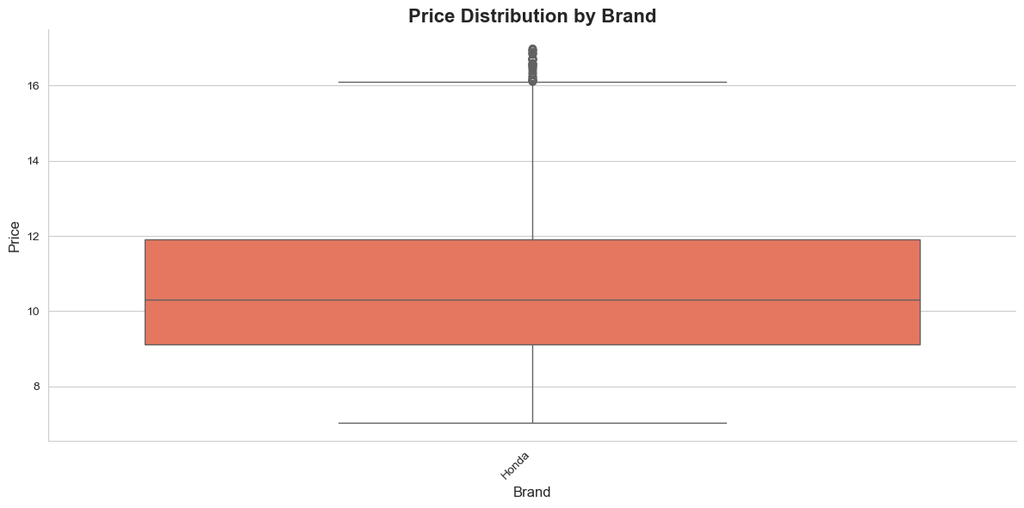

```python
import seaborn as sns
import matplotlib.pyplot as plt

plt.figure(figsize=(12,6))
sns.set_style("whitegrid")  # Clean background

sns.boxplot(
    x="Brand",
    y="Price",
    hue="Brand",        # add hue
    data=honda_data,
    palette="Reds",
    legend=False        # avoid duplicate legend
)


plt.xticks(rotation=45, ha="right", fontsize=10)
plt.title("Price Distribution by Brand", fontsize=16, fontweight="bold")
plt.xlabel("Brand", fontsize=12)
plt.ylabel("Price", fontsize=12)

sns.despine()  # Remove top & right spines
plt.tight_layout()
plt.show()
```

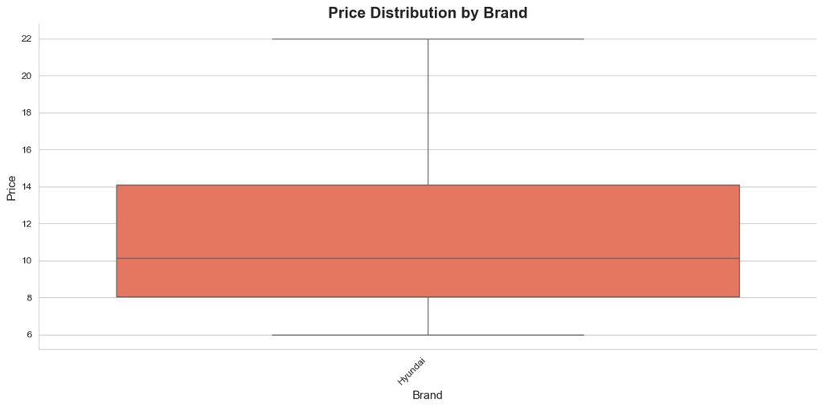

```python
import seaborn as sns
import matplotlib.pyplot as plt

plt.figure(figsize=(12,6))
sns.set_style("whitegrid")  # Clean background

sns.boxplot(
    x="Brand",
    y="Price",
    hue="Brand",        # add hue
    data=hyundai_data,
    palette="Reds",
    legend=False        # avoid duplicate legend
)


plt.xticks(rotation=45, ha="right", fontsize=10)
plt.title("Price Distribution by Brand", fontsize=16, fontweight="bold")
plt.xlabel("Brand", fontsize=12)
plt.ylabel("Price", fontsize=12)

sns.despine()  # Remove top & right spines
plt.tight_layout()
plt.show()
```

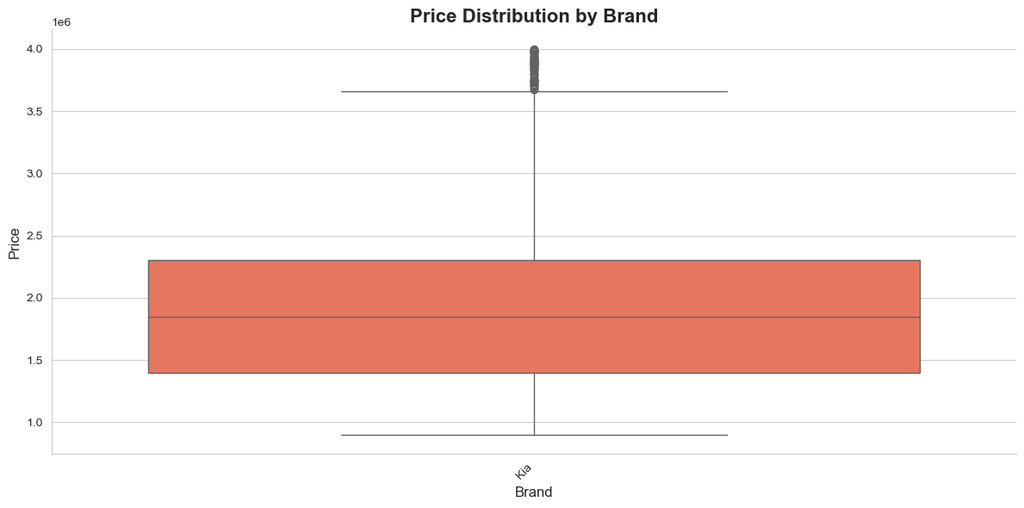

```python
import seaborn as sns
import matplotlib.pyplot as plt

plt.figure(figsize=(12,6))
sns.set_style("whitegrid")  # Clean background

sns.boxplot(
    x="Brand",
    y="Price",
    hue="Brand",        # add hue
    data=kia_data,
    palette="Reds",
    legend=False        # avoid duplicate legend
)


plt.xticks(rotation=45, ha="right", fontsize=10)
plt.title("Price Distribution by Brand", fontsize=16, fontweight="bold")
plt.xlabel("Brand", fontsize=12)
plt.ylabel("Price", fontsize=12)

sns.despine()  # Remove top & right spines
plt.tight_layout()
plt.show()
```

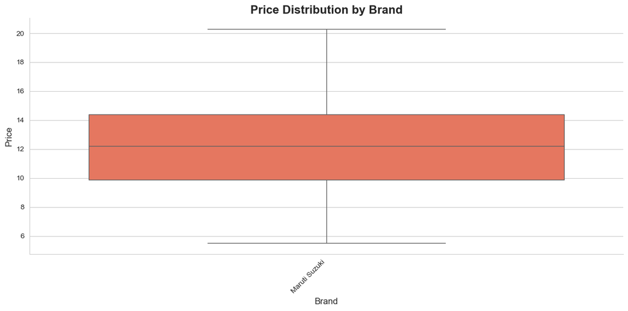

```python
import seaborn as sns
import matplotlib.pyplot as plt

plt.figure(figsize=(12,6))
sns.set_style("whitegrid")  # Clean background

sns.boxplot(
    x="Brand",
    y="Price",
    hue="Brand",        # add hue
    data=maruti_a_data,
    palette="Reds",
    legend=False        # avoid duplicate legend
)


plt.xticks(rotation=45, ha="right", fontsize=10)
plt.title("Price Distribution by Brand", fontsize=16, fontweight="bold")
plt.xlabel("Brand", fontsize=12)
plt.ylabel("Price", fontsize=12)

sns.despine()  # Remove top & right spines
plt.tight_layout()
plt.show()
```

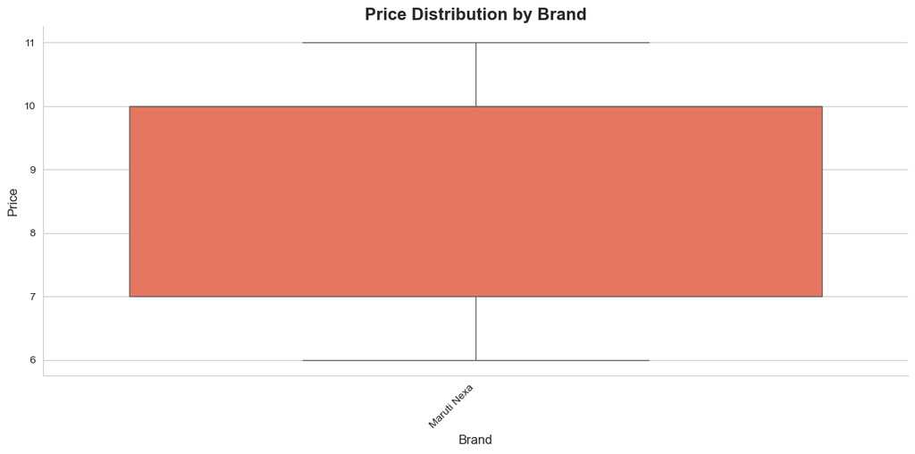

```python
import seaborn as sns
import matplotlib.pyplot as plt

plt.figure(figsize=(12,6))
sns.set_style("whitegrid")  # Clean background

sns.boxplot(
    x="Brand",
    y="Price",
    hue="Brand",        # add hue
    data=maruti_n_data,
    palette="Reds",
    legend=False        # avoid duplicate legend
)


plt.xticks(rotation=45, ha="right", fontsize=10)
plt.title("Price Distribution by Brand", fontsize=16, fontweight="bold")
plt.xlabel("Brand", fontsize=12)
plt.ylabel("Price", fontsize=12)

sns.despine()  # Remove top & right spines
plt.tight_layout()
plt.show()
```

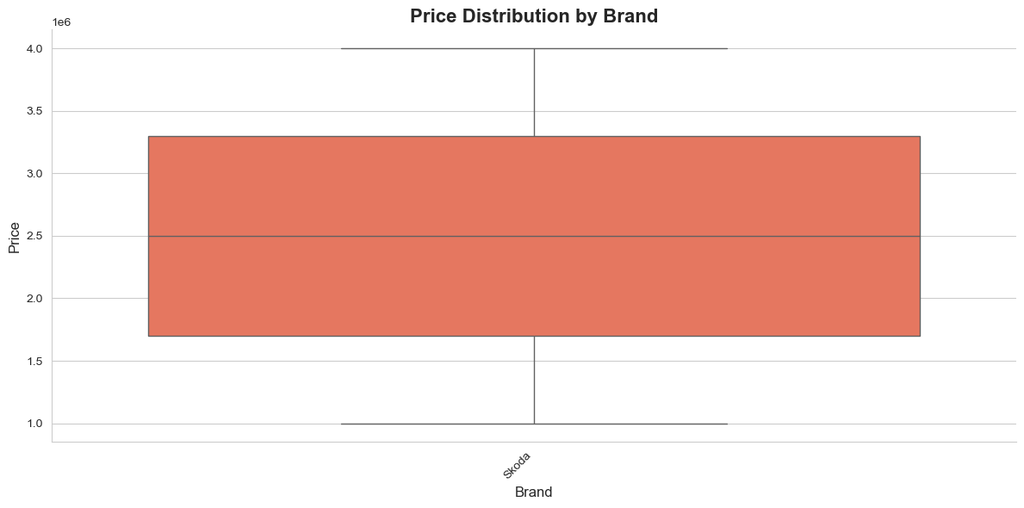

```python
import seaborn as sns
import matplotlib.pyplot as plt

plt.figure(figsize=(12,6))
sns.set_style("whitegrid")  # Clean background

sns.boxplot(
    x="Brand",
    y="Price",
    hue="Brand",        # add hue
    data=skoda_data,
    palette="Reds",
    legend=False        # avoid duplicate legend
)


plt.xticks(rotation=45, ha="right", fontsize=10)
plt.title("Price Distribution by Brand", fontsize=16, fontweight="bold")
plt.xlabel("Brand", fontsize=12)
plt.ylabel("Price", fontsize=12)

sns.despine()  # Remove top & right spines
plt.tight_layout()
plt.show()
```

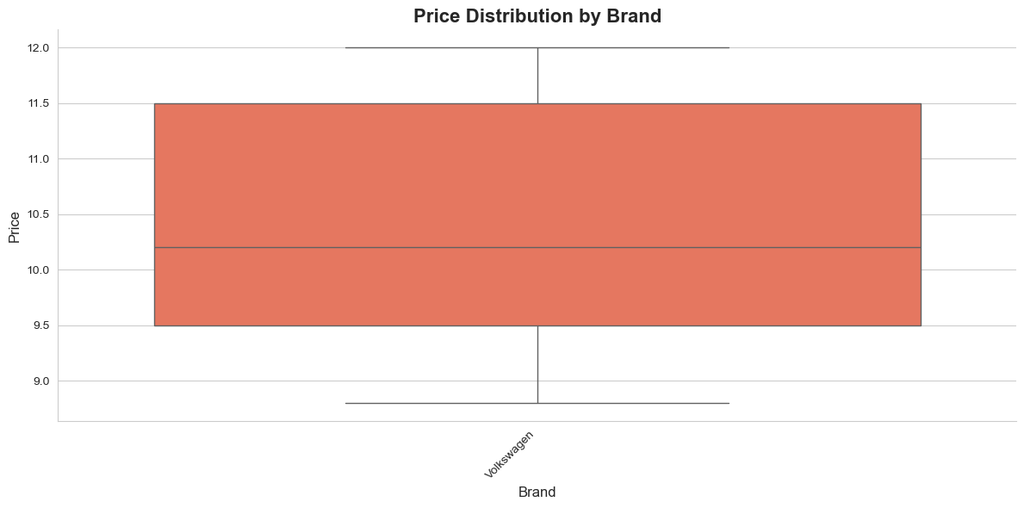

```python
import seaborn as sns
import matplotlib.pyplot as plt

plt.figure(figsize=(12,6))
sns.set_style("whitegrid")  # Clean background

sns.boxplot(
    x="Brand",
    y="Price",
    hue="Brand",        # add hue
    data=vw_data,
    palette="Reds",
    legend=False        # avoid duplicate legend
)


plt.xticks(rotation=45, ha="right", fontsize=10)
plt.title("Price Distribution by Brand", fontsize=16, fontweight="bold")
plt.xlabel("Brand", fontsize=12)
plt.ylabel("Price", fontsize=12)

sns.despine()  # Remove top & right spines
plt.tight_layout()
plt.show()
```

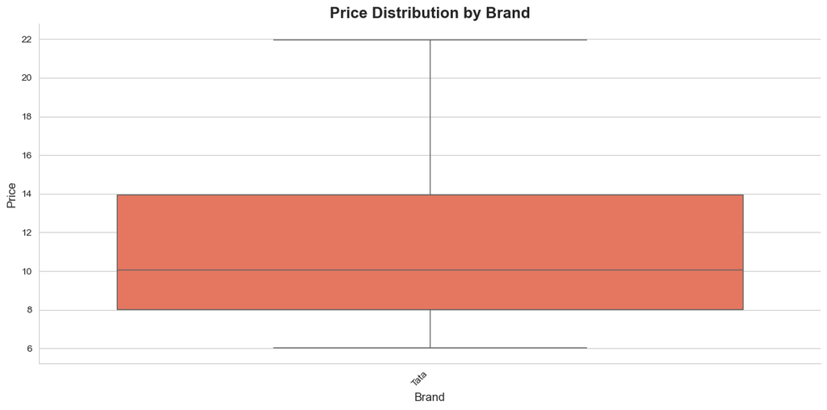

```python
import seaborn as sns
import matplotlib.pyplot as plt

plt.figure(figsize=(12,6))
sns.set_style("whitegrid")  # Clean background

sns.boxplot(
    x="Brand",
    y="Price",
    hue="Brand",        # add hue
    data=tata_data,
    palette="Reds",
    legend=False        # avoid duplicate legend
)


plt.xticks(rotation=45, ha="right", fontsize=10)
plt.title("Price Distribution by Brand", fontsize=16, fontweight="bold")
plt.xlabel("Brand", fontsize=12)
plt.ylabel("Price", fontsize=12)

sns.despine()  # Remove top & right spines
plt.tight_layout()
plt.show()
```

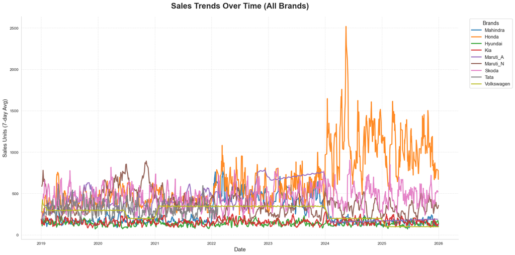

```python
import matplotlib.pyplot as plt
import seaborn as sns
import pandas as pd

# ✅ Load datasets
datasets = {
    "Mahindra": r"C:\Users\smcho\OneDrive\Desktop\Project 101\Real-Life-Project-Based-on-Automobile-Industry-\data\mahindra_dataset.csv",
    "Honda": r"C:\Users\smcho\OneDrive\Desktop\Project 101\Real-Life-Project-Based-on-Automobile-Industry-\data\honda_dataset.csv",
    "Hyundai": r"C:\Users\smcho\OneDrive\Desktop\Project 101\Real-Life-Project-Based-on-Automobile-Industry-\data\hyundai_dataset.csv",
    "Kia": r"C:\Users\smcho\OneDrive\Desktop\Project 101\Real-Life-Project-Based-on-Automobile-Industry-\data\kia_dataset.csv",
    "Maruti_A": r"C:\Users\smcho\OneDrive\Desktop\Project 101\Real-Life-Project-Based-on-Automobile-Industry-\data\Maruti_A_dataset.csv",
    "Maruti_N": r"C:\Users\smcho\OneDrive\Desktop\Project 101\Real-Life-Project-Based-on-Automobile-Industry-\data\maruti_n_dataset.csv",
    "Skoda": r"C:\Users\smcho\OneDrive\Desktop\Project 101\Real-Life-Project-Based-on-Automobile-Industry-\data\skoda_dataset.csv",
    "Tata": r"C:\Users\smcho\OneDrive\Desktop\Project 101\Real-Life-Project-Based-on-Automobile-Industry-\data\tata_dataset.csv",
    "Volkswagen": r"C:\Users\smcho\OneDrive\Desktop\Project 101\Real-Life-Project-Based-on-Automobile-Industry-\data\vw_dataset.csv"
}

# ✅ Clean + Aggregate Function
def process_sales(file_path):
    df = pd.read_csv(file_path)
    df["SaleDate"] = pd.to_datetime(df["SaleDate"], dayfirst=True, errors="coerce")
    df = df.dropna(subset=["SaleDate"])
    sales = df.groupby("SaleDate")["SalesUnits"].sum().reset_index()
    sales["Rolling"] = sales["SalesUnits"].rolling(window=7, min_periods=1).mean()  # smooth trend
    return sales

# ✅ Apply processing for all brands
brand_sales = {brand: process_sales(path) for brand, path in datasets.items()}

# ✅ Plot all brands
plt.figure(figsize=(18,9))
sns.set_style("whitegrid")
palette = sns.color_palette("tab10", n_colors=len(brand_sales))

for (brand, sales), color in zip(brand_sales.items(), palette):
    plt.plot(sales["SaleDate"], sales["Rolling"], linewidth=2.5, label=brand, color=color, alpha=0.9)

# ✅ Beautify
plt.title("Sales Trends Over Time (All Brands)", fontsize=20, fontweight="bold", pad=20)
plt.xlabel("Date", fontsize=14)
plt.ylabel("Sales Units (7-day Avg)", fontsize=14)
plt.legend(title="Brands", bbox_to_anchor=(1.02, 1), loc="upper left", fontsize=12, title_fontsize=13)
plt.grid(True, linestyle="--", alpha=0.5)
sns.despine()
plt.tight_layout()
plt.show()
```

### Exploratory Data Analysis

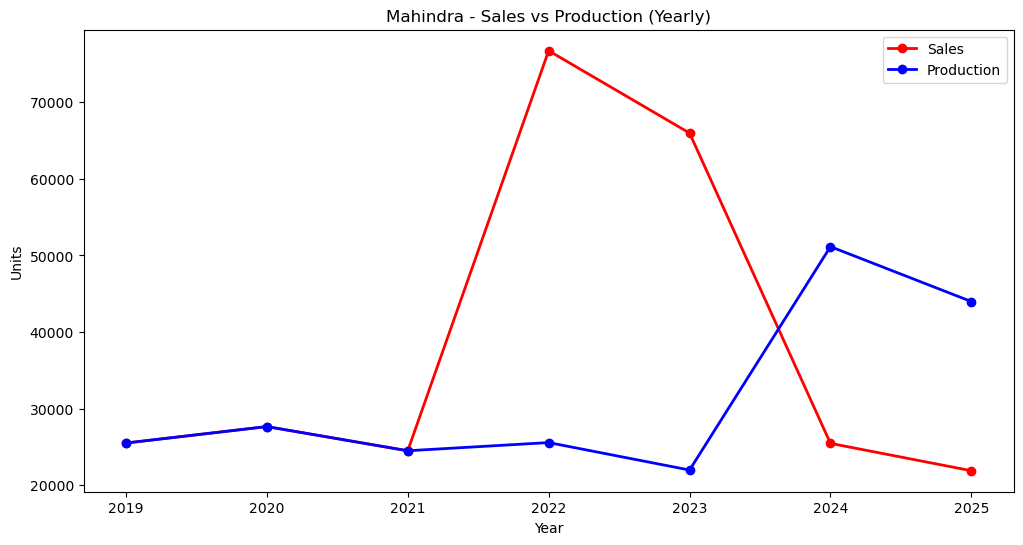

```python
yearly_data = mahindra_data.groupby('Year')[['SalesUnits', 'ProductionUnits']].sum().reset_index()

plt.figure(figsize=(12,6))
plt.plot(
    yearly_data['Year'], yearly_data['SalesUnits'],
    label='Sales', marker='o', color="red", linewidth=2
)
plt.plot(
    yearly_data['Year'], yearly_data['ProductionUnits'],
    label='Production', marker='o', color="blue", linewidth=2
)

plt.xlabel("Year")
plt.ylabel("Units")
plt.title("Mahindra - Sales vs Production (Yearly)")
plt.legend()
plt.show()
```

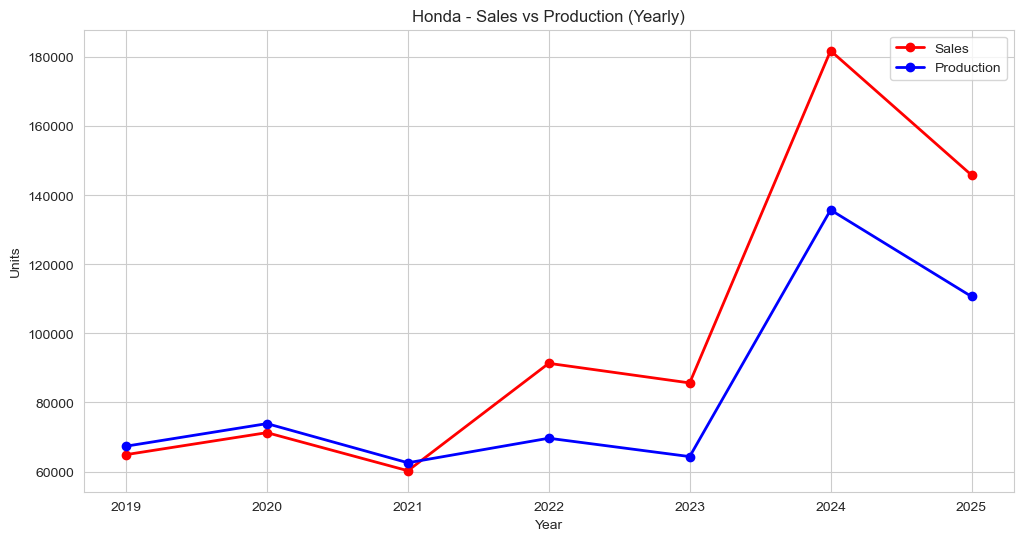

```python
yearly_data = honda_data.groupby('Year')[['SalesUnits', 'ProductionUnits']].sum().reset_index()

plt.figure(figsize=(12,6))
plt.plot(
    yearly_data['Year'], yearly_data['SalesUnits'],
    label='Sales', marker='o', color="red", linewidth=2
)
plt.plot(
    yearly_data['Year'], yearly_data['ProductionUnits'],
    label='Production', marker='o', color="blue", linewidth=2
)

plt.xlabel("Year")
plt.ylabel("Units")
plt.title("Honda - Sales vs Production (Yearly)")
plt.legend()
plt.show()
```

[figure not shown]

```python
yearly_data = hyundai_data.groupby('Year')[['SalesUnits', 'ProductionUnits']].sum().reset_index()

plt.figure(figsize=(12,6))
plt.plot(
    yearly_data['Year'], yearly_data['SalesUnits'],
    label='Sales', marker='o', color="red", linewidth=2
)
plt.plot(
    yearly_data['Year'], yearly_data['ProductionUnits'],
    label='Production', marker='o', color="blue", linewidth=2
)

plt.xlabel("Year")
plt.ylabel("Units")
plt.title("Hyundai - Sales vs Production (Yearly)")
plt.legend()
plt.show()
```

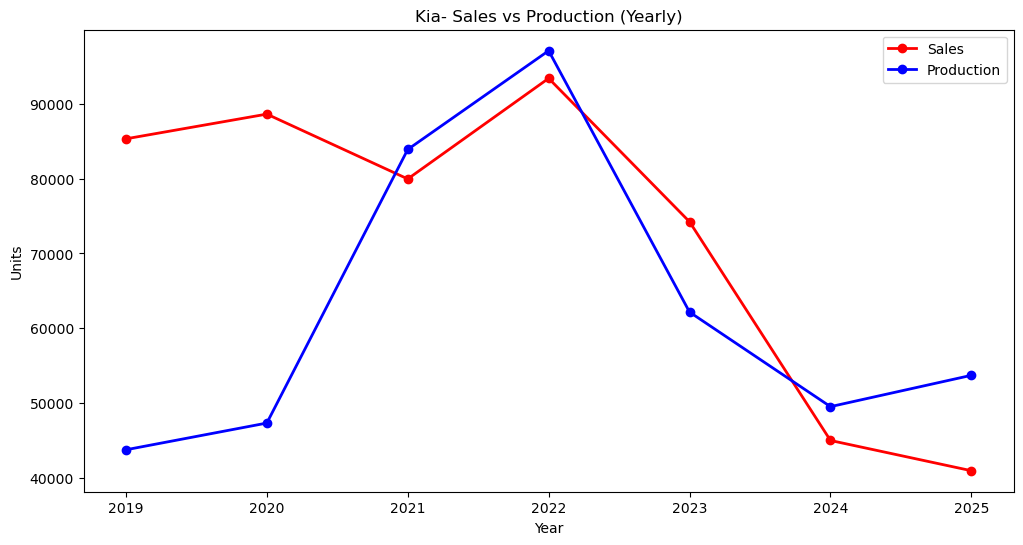

```python
yearly_data = kia_data.groupby('Year')[['SalesUnits', 'ProductionUnits']].sum().reset_index()

plt.figure(figsize=(12,6))
plt.plot(
    yearly_data['Year'], yearly_data['SalesUnits'],
    label='Sales', marker='o', color="red", linewidth=2
)
plt.plot(
    yearly_data['Year'], yearly_data['ProductionUnits'],
    label='Production', marker='o', color="blue", linewidth=2
)

plt.xlabel("Year")
plt.ylabel("Units")
plt.title("Kia- Sales vs Production (Yearly)")
plt.legend()
plt.show()
```

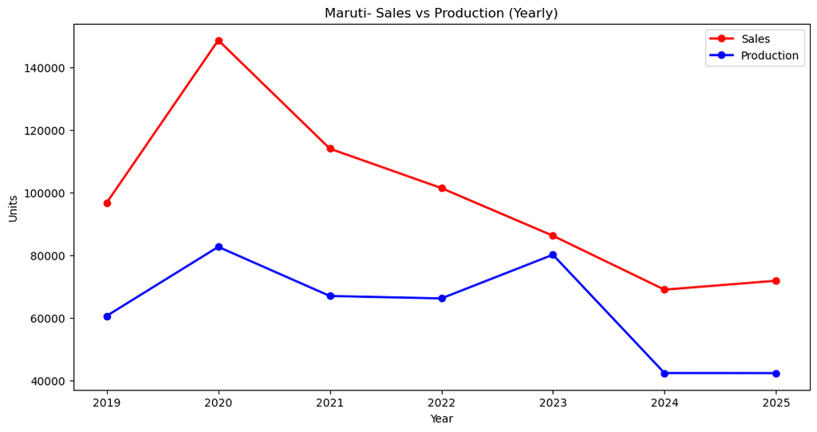

```python
yearly_data = maruti_n_data.groupby('Year')[['SalesUnits', 'ProductionUnits']].sum().reset_index()

plt.figure(figsize=(12,6))
plt.plot(
    yearly_data['Year'], yearly_data['SalesUnits'],
    label='Sales', marker='o', color="red", linewidth=2
)
plt.plot(
    yearly_data['Year'], yearly_data['ProductionUnits'],
    label='Production', marker='o', color="blue", linewidth=2
)

plt.xlabel("Year")
plt.ylabel("Units")
plt.title("Maruti- Sales vs Production (Yearly)")
plt.legend()
plt.show()
```

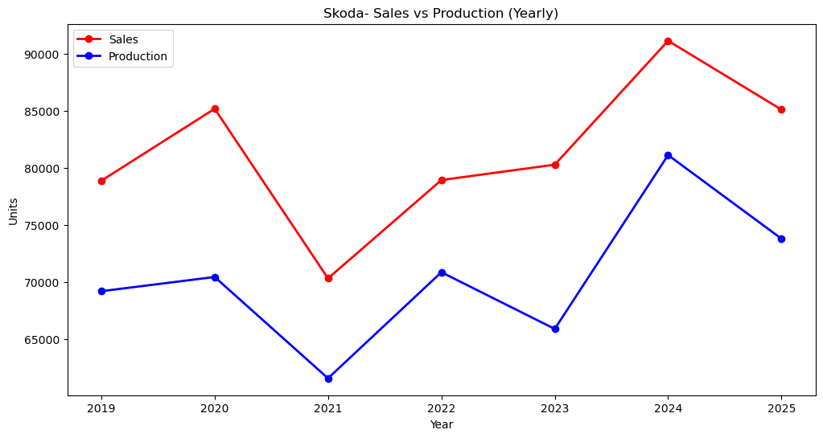

```python
yearly_data = skoda_data.groupby('Year')[['SalesUnits', 'ProductionUnits']].sum().reset_index()

plt.figure(figsize=(12,6))
plt.plot(
    yearly_data['Year'], yearly_data['SalesUnits'],
    label='Sales', marker='o', color="red", linewidth=2
)
plt.plot(
    yearly_data['Year'], yearly_data['ProductionUnits'],
    label='Production', marker='o', color="blue", linewidth=2
)

plt.xlabel("Year")
plt.ylabel("Units")
plt.title("Skoda- Sales vs Production (Yearly)")
plt.legend()
plt.show()
```

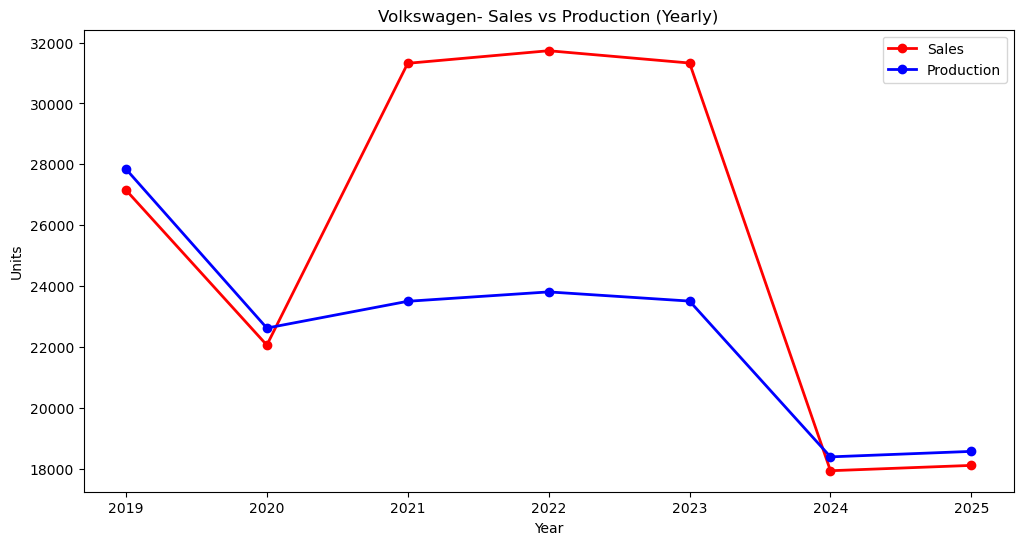

```python
yearly_data = vw_data.groupby('Year')[['SalesUnits', 'ProductionUnits']].sum().reset_index()

plt.figure(figsize=(12,6))
plt.plot(
    yearly_data['Year'], yearly_data['SalesUnits'],
    label='Sales', marker='o', color="red", linewidth=2
)
plt.plot(
    yearly_data['Year'], yearly_data['ProductionUnits'],
    label='Production', marker='o', color="blue", linewidth=2
)

plt.xlabel("Year")
plt.ylabel("Units")
plt.title("Volkswagen- Sales vs Production (Yearly)")
plt.legend()
plt.show()
```

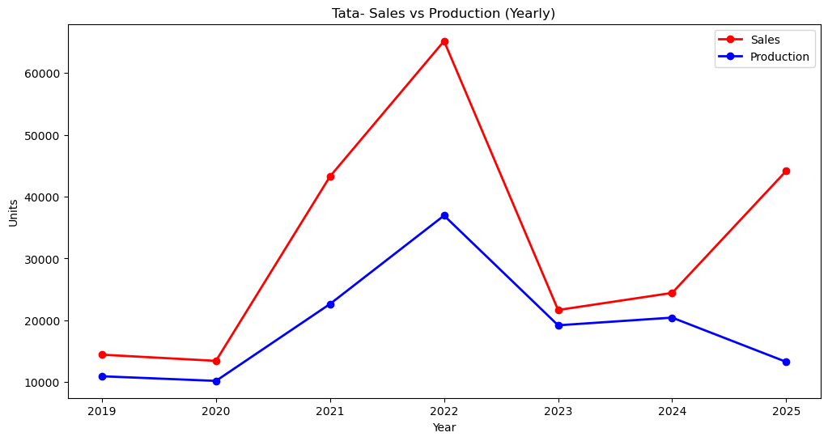

```python
yearly_data = tata_data.groupby('Year')[['SalesUnits', 'ProductionUnits']].sum().reset_index()

plt.figure(figsize=(12,6))
plt.plot(
    yearly_data['Year'], yearly_data['SalesUnits'],
    label='Sales', marker='o', color="red", linewidth=2
)
plt.plot(
    yearly_data['Year'], yearly_data['ProductionUnits'],
    label='Production', marker='o', color="blue", linewidth=2
)

plt.xlabel("Year")
plt.ylabel("Units")
plt.title("Tata- Sales vs Production (Yearly)")
plt.legend()
plt.show()
```

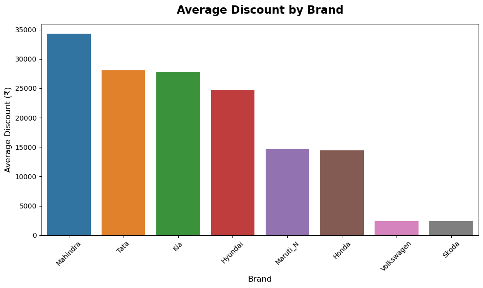

```python
import pandas as pd
import matplotlib.pyplot as plt
import matplotlib
import seaborn as sns

# ✅ Load all datasets into a dictionary
datasets = {
    "Mahindra": mahindra_data,
    "Honda": honda_data,
    "Hyundai": hyundai_data,
    "Kia": kia_data,
    "Maruti_N": maruti_n_data,
    "Skoda": skoda_data,
    "Tata": tata_data,
    "Volkswagen": vw_data
}

# ✅ Add Brand column & merge all
all_data = pd.concat(
    [df.assign(Brand=brand) for brand, df in datasets.items()],
    ignore_index=True
)

# ✅ Average discount per brand
avg_discount = (
    all_data.groupby('Brand', observed=False)['Discount']
    .mean()
    .reset_index()
    .sort_values('Discount', ascending=False)  # sort for better visualization
)

# 🎨 Plot
matplotlib.rcParams['font.family'] = 'DejaVu Sans'
plt.figure(figsize=(10,6))
sns.barplot(
    x="Brand",
    y="Discount",
    data=avg_discount,
    palette="tab10"
)

plt.xlabel("Brand", fontsize=12)
plt.ylabel("Average Discount (₹)", fontsize=12)
plt.title("Average Discount by Brand", fontsize=16, fontweight="bold", pad=15)
plt.xticks(rotation=45)
plt.tight_layout()
plt.show()
```

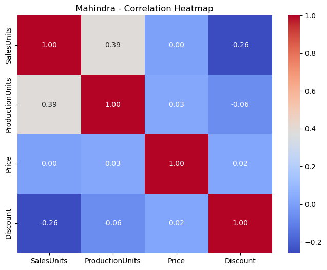

```python
# Mahindra
plt.figure(figsize=(8,6))
sns.heatmap(
    mahindra_data[['SalesUnits','ProductionUnits','Price','Discount']].corr(),
    annot=True, cmap="coolwarm", fmt=".2f"
)
plt.title("Mahindra - Correlation Heatmap")
plt.show()
```

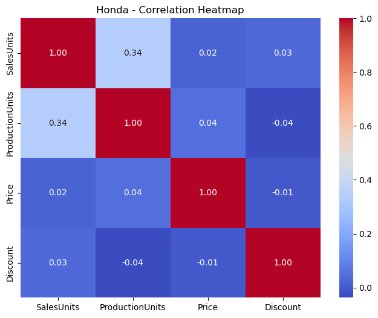

```python
# Honda
plt.figure(figsize=(8,6))
sns.heatmap(
    honda_data[['SalesUnits','ProductionUnits','Price','Discount']].corr(),
    annot=True, cmap="coolwarm", fmt=".2f"
)
plt.title("Honda - Correlation Heatmap")
plt.show()
```

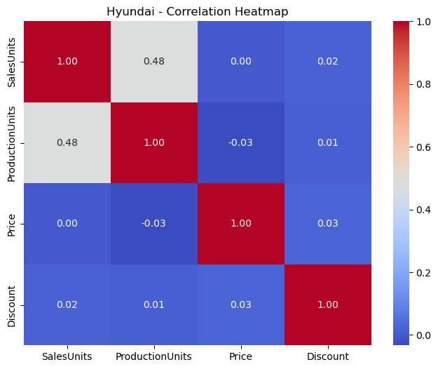

```python
# Hyundai
plt.figure(figsize=(8,6))
sns.heatmap(
    hyundai_data[['SalesUnits','ProductionUnits','Price','Discount']].corr(),
    annot=True, cmap="coolwarm", fmt=".2f"
)
plt.title("Hyundai - Correlation Heatmap")
plt.show()
```

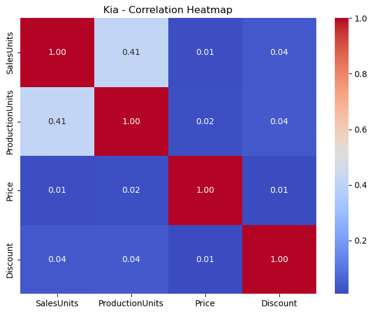

```python
# Kia
plt.figure(figsize=(8,6))
sns.heatmap(
    kia_data[['SalesUnits','ProductionUnits','Price','Discount']].corr(),
    annot=True, cmap="coolwarm", fmt=".2f"
)
plt.title("Kia - Correlation Heatmap")
plt.show()
```

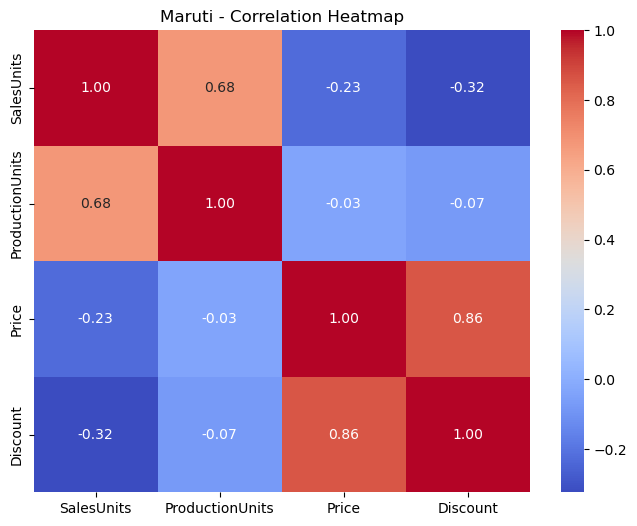

```python
# Maruti
plt.figure(figsize=(8,6))
sns.heatmap(
    maruti_n_data[['SalesUnits','ProductionUnits','Price','Discount']].corr(),
    annot=True, cmap="coolwarm", fmt=".2f"
)
plt.title("Maruti - Correlation Heatmap")
plt.show()
```